# Key 06 t-tests

## Problem 4: paired t-test

### Data: `darwin_maize`

As mentioned in class, Darwin’s maize experiment was looking at the difference in height for self- and cross-pollinated plants. - The study design that Darwin employed was actually a paired design, in which he raised paired individuals (one self- and one cross-pollinated) in the same pot. - This is a method for controlling for unintended variation in conditions. - For example, maybe pair 1 had less water or nutrients, so both individuals came out shorter that would be expected. - Instead of averaging across all self- and cross-pollinated individuals, we can analyze this data as a paired design and only look at the *difference* in heights among the pairs.

If you haven’t already, read the `darwin_maize.csv` file into R.

```r
darwin_maize <- read_csv("data/darwin_maize.csv")
```

4.1 Add a comment to your homework script stating the null and alternative hypotheses for a paired t-test analysis. Make sure to put each hypothesis on its own line. Make sure that your alternative hypothesis is 2-tailed.

```r
# there is no average difference between the two groups (Self V Cross): \mu_d = 0
# There is a difference between the two groups: \mu_d \ne 0
```

4.2. Make a new data object called `darwin_diff` which includes the `difference` in `heights` for each `pair` in the data set. + As in the lab, the way the data is structured does not make this task simple, but we can use `group_by()` function before using the `-diff()` function inside of `mutate()` to accomplish this.  
+ See the `caterpillar` example from the lab.  
+ **Hint** your new object should contain the following columns: `pair` and `difference`.  
+ Make sure to print out your new `darwin_diff` object at the end of this problem.

```r
darwin_diff <- darwin_maize |>
  group_by(pair) |>
  summarize(difference = -diff(height))

darwin_diff
```

```
# A tibble: 15 × 2
    pair difference
   <dbl>      <dbl>
 1     1       6.12
 2     2      -8.38
 3     3       1
 4     4       2
 5     5       0.75
 6     6       2.88
 7     7       3.5
 8     8       5.12
 9     9       1.75
10    10       3.62
11    11       7
12    12       3
13    13       9.38
14    14       7.5
15    15      -6
```

## 4.3 GRADED boxplot

4.3 Make a box plot of the difference in plant heights and include a reference line at 0. Be sure to use the `darwin_diff` object you created above.

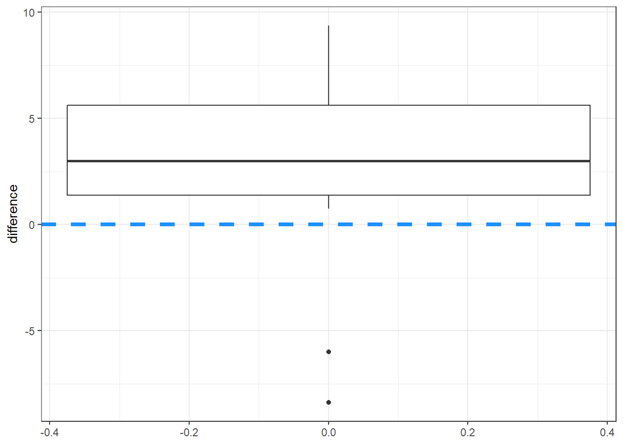

```r
ggplot(data = darwin_diff,
       aes(y = difference)) +
  geom_boxplot() +
  geom_hline(yintercept = 0,
             linewidth = 1.5,
             linetype = "dashed",
             color = "dodgerblue") +
  theme_bw()
```

4.4 Add a comment to your script making a prediction: Do you think the average differences are going to be different from 0? Why or why not?

```r
# Not graded, just looking for interpretation and that you are thinking about the data and hypotheses.
```

4.5 Use `lm()` function to formally test your hypothesis.  
+ Store the output of `lm()` in a new data object, and then use the `summary()` function to print out the results.

```r
paired_fit <- lm(difference ~ 1, data = darwin_diff)
summary(paired_fit)
```

```
Call:
lm(formula = difference ~ 1, data = darwin_diff)

Residuals:
     Min       1Q   Median       3Q      Max
-10.9917  -1.2417   0.3833   3.0083   6.7583

Coefficients:
            Estimate Std. Error t value Pr(>|t|)
(Intercept)    2.617      1.218   2.148   0.0497 *
---
Signif. codes:  0 '***' 0.001 '**' 0.01 '*' 0.05 '.' 0.1 ' ' 1

Residual standard error: 4.718 on 14 degrees of freedom
```

## 4.6 GRADED 2.617 $\pm$ 1.218

4.6 Add a comment to your script describing the estimated average and standard error for the difference between the two groups.

```r
# estimated average difference  between cross and self groups = 2.617 \pm 1.218
```

4.7 Add a comment to your script interpreting the results of your analysis. Be sure to refer back to the null and alternative hypotheses (reject or fail to reject?) include the t-statistic, the degrees of freedom, and the p-value in your answer.

```r
# Based on the data, we reject the null hypothesis and conclude that there is a difference in height between the sel- and cross-pollinated groups (t-stat = 2.15, p = 0.0497, df = 14)
```